# a3_task4_adriane_mcdonald

Adriane McDonald

11/6/2020

# TASK 4: Naples Reef (January 2010) purple urchins

**Data:** Reed, D. 2020. SBC LTER: Reef: Long-term experiment: Kelp removal: Urchin size frequency distribution ver 20. Environmental Data Initiative. [DOI](https://portal.edirepository.org/nis/mapbrowse?packageid=knb-lter-sbc.26.20)

## Read in the Urchins data

Use janitor package to clean variable names

```r
urchins_data_task4 <- read_csv(here("data", "urchins.csv")) %>%
  clean_names()
```

## Compare the mean size of purple urchins in CONTROL or ANNUAL sections of Naples Reef in January 2010

### Wrangle urchins data

Include only Naples Reef observations for purple urchins observed in January 2010

After each line, make sure to look at dataset to ensure you remain on the right path.

```r
naples_urchins <- urchins_data_task4 %>%
  filter(common_name == "Purple Urchin", site == "NAPL") %>%
  mutate(date_new = mdy(date)) %>%
  mutate(year_new = year(date_new)) %>%
  mutate(month_new = month(date_new)) %>%
  mutate(full_site_name = case_when(
    site == "NAPL" ~ "Naples Reef")) %>%
  filter(year_new == "2010", month_new == "1")
```

### Data Visualization

#### Use exploratory graphs to look at the size distribution for each treatment (control and annual) to assess normality

Here, I will be using a histogram to assess size distribution and normality for the two treatments. This is not a final graph.

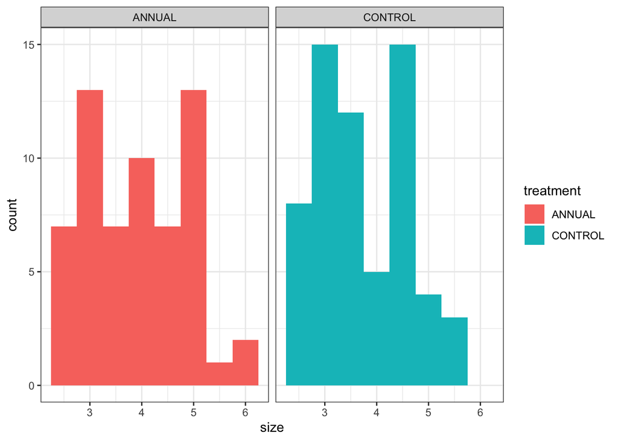

```r
ggplot(data = naples_urchins, aes(x = size, fill = treatment))+
  geom_histogram(bins = 8)+
  facet_wrap(~treatment)+
  theme_bw()
```

This exploratory graph does not show much about the size distribution for each treatment, but it does appear that the distribution of urchin sizes for both treatments are very similar and are fairly normal.

### Descriptive Statistics

#### Creation of a table containing the mean, std, and sample size (at least)

```r
naples_urchin_stats <- naples_urchins %>%
  group_by(treatment) %>%
  summarize(mean = mean(size),
            sd = sd(size),
            sample_size = n(),
            median = median(size)) %>%
  kbl() %>%
  kable_classic_2(full_width = F)

naples_urchin_stats
```

| treatment | mean | sd | sample_size | median |
| --- | --- | --- | --- | --- |
| ANNUAL | 3.916667 | 0.9662380 | 60 | 4.0 |
| CONTROL | 3.725807 | 0.8668646 | 62 | 3.5 |

### Two Sample T-Test

Two Sample T-test to compare means between the two treatment groups

```r
annual_sample <- naples_urchins %>%
  filter(treatment == "ANNUAL") %>%
  pull(size)

control_sample <- naples_urchins %>%
  filter(treatment == "CONTROL") %>%
  pull(size)

t.test(x = annual_sample, y = control_sample)
```

```
##
##  Welch Two Sample t-test
##
## data:  annual_sample and control_sample
## t = 1.1472, df = 117.66, p-value = 0.2536
## alternative hypothesis: true difference in means is not equal to 0
## 95 percent confidence interval:
##  -0.1386165  0.5203369
## sample estimates:
## mean of x mean of y
##  3.916667  3.725806
```

```r
sd(annual_sample)
```

```
## [1] 0.966238
```

```r
sd(control_sample)
```

```
## [1] 0.8668646
```